# Iris Dataset Statistics Lab

Cristian Santiago

# Libraries

```r
library(tidyverse)
```

# Load the iris dataset

```r
data(iris)
```

```r
# Changing names of each column
colnames(iris) <- c("SepalLen", "SepalWid", "PetalLen", "PetalWid", "Species")
```

```r
# checking  first few rows
head(iris)
```

|  | SepalLen | SepalWid | PetalLen | PetalWid | Species |
| --- | --- | --- | --- | --- | --- |
| 1 | 5.1 | 3.5 | 1.4 | 0.2 | setosa |
| 2 | 4.9 | 3.0 | 1.4 | 0.2 | setosa |
| 3 | 4.7 | 3.2 | 1.3 | 0.2 | setosa |
| 4 | 4.6 | 3.1 | 1.5 | 0.2 | setosa |
| 5 | 5.0 | 3.6 | 1.4 | 0.2 | setosa |
| 6 | 5.4 | 3.9 | 1.7 | 0.4 | setosa |

## Questions:

1. How many numeric columns are in the dataset?

Four Columns

2. How many species are included?

Three species

3. What is the range of SepalLen? (min and max)

# Summary Statistics

Calculate mean, median, variance, SD for numeric columns

```r
sapply(iris[,1:4], mean)
```

```
## SepalLen SepalWid PetalLen PetalWid
## 5.843333 3.057333 3.758000 1.199333
```

```r
sapply(iris[,1:4], median)
```

```
## SepalLen SepalWid PetalLen PetalWid
##     5.80     3.00     4.35     1.30
```

```r
sapply(iris[,1:4], var)
```

```
##  SepalLen  SepalWid  PetalLen  PetalWid
## 0.6856935 0.1899794 3.1162779 0.5810063
```

```r
sapply(iris[,1:4], sd)
```

```
##  SepalLen  SepalWid  PetalLen  PetalWid
## 0.8280661 0.4358663 1.7652982 0.7622377
```

## Questions:

# Summary by Species

```r
aggregate(SepalLen ~ Species, data=iris, FUN=mean)
```

| Species | SepalLen |
| --- | --- |
| setosa | 5.006 |
| versicolor | 5.936 |
| virginica | 6.588 |

```r
aggregate(PetalWid ~ Species, data=iris, FUN=var)
```

| Species | PetalWid |
| --- | --- |
| setosa | 0.01110612 |
| versicolor | 0.03910612 |
| virginica | 0.07543265 |

## Questions:

1. Which species has the largest SepalLen on average? Virginica has the largest SepalLen on average.
2. Which species shows the most variability in PetalWid? Virginica shows the most variability in PetalWid.
3. What does this tell you about the characteristics of different species This shows that different species have different sizes and variation, which helps tell them apat.

# Visualizations

### Histogram of SepalLen

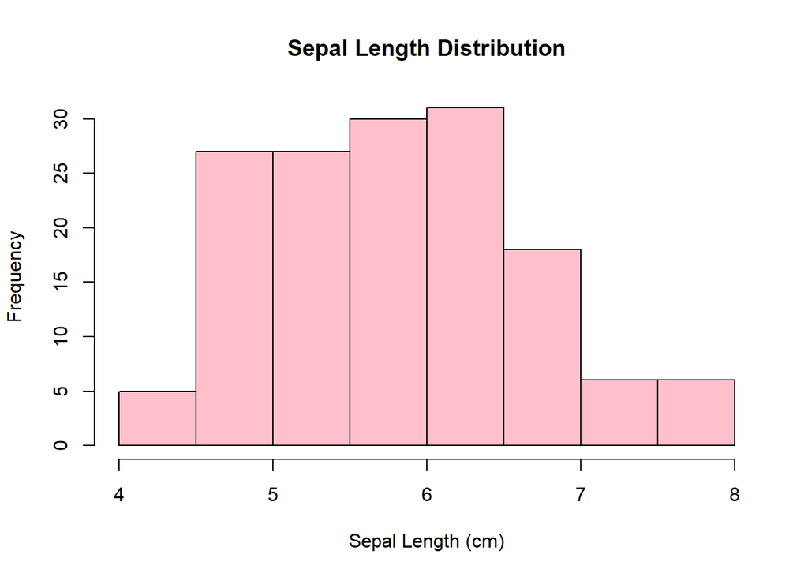

```r
hist(iris$SepalLen,
     main="Sepal Length Distribution",
     xlab="Sepal Length (cm)",
     col="pink",
     border="black")
```

## Questions:

1. What is the shape of the distribution (symmetric, skewed)? this distribution shows a light right skew.
2. Are there any unusually low or high values? There are no obvious outliers, just some small values that slightly stand out.

# Boxplot of PetalLen by Species

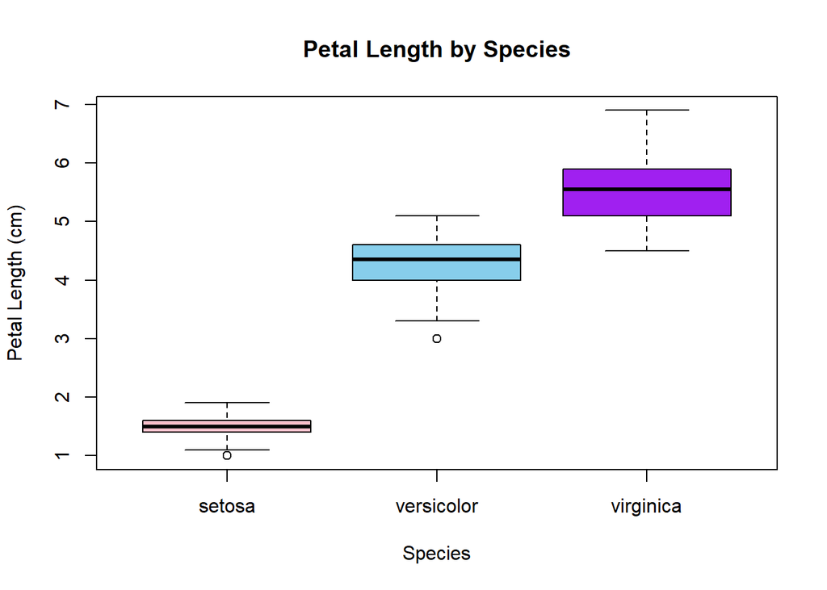

```r
boxplot(PetalLen ~ Species,
        data=iris,
        main="Petal Length by Species",
        ylab="Petal Length (cm)",
        col=c("pink","skyblue","purple"))
```

## Questions:

# Correlation Matrix

```r
cor_matrix <- cor(iris[,1:4])
cor_matrix
```

```
##            SepalLen   SepalWid   PetalLen   PetalWid
## SepalLen  1.0000000 -0.1175698  0.8717538  0.8179411
## SepalWid -0.1175698  1.0000000 -0.4284401 -0.3661259
## PetalLen  0.8717538 -0.4284401  1.0000000  0.9628654
## PetalWid  0.8179411 -0.3661259  0.9628654  1.0000000
```

## Questions:

1. Which two variables are most strongly correlated? PetalLen and PetalWid are the most strongly correlated.
2. Are there any weak or negative correlations? SepalWid has weaker and slightly negative correlations with some variables.
3. How might these correlations help distinguish species? These correlations help separate species because petal size is very different across them.

# Interpretation

Write a short paragraph (3-5 sentences) answering:

- Which variables best distinguish species?
- How could a scientist use these statistics in real life?
- Do the histograms, boxplots, and correlations tell a consistent story?

PetalLen and PetalWid are the best for telling the species apart because they look really different for each group. A scientist could use these measurements to figure out what type of plant they’re looking at or notice patterns. The graphs and correlations all point to the same thing, which is that petal size matters the most.